# Настройка DNS-сервера

Лабораторная работа №2

Элсаиед Адел

Российский университет дружбы народов, Москва, Россия

2 января 2026

# Цели и задачи работы

## Цель лабораторной работы

Приобретение практических навыков установки и конфигурирования DNS-сервера на базе BIND, а также изучение принципов работы системы доменных имён.

# Выполнение работы

## Установка DNS-сервера

На виртуальной машине server выполнена установка пакетов bind и bind-utils.  
В процессе установки были автоматически разрешены зависимости и подготовлена среда для работы DNS-сервера.

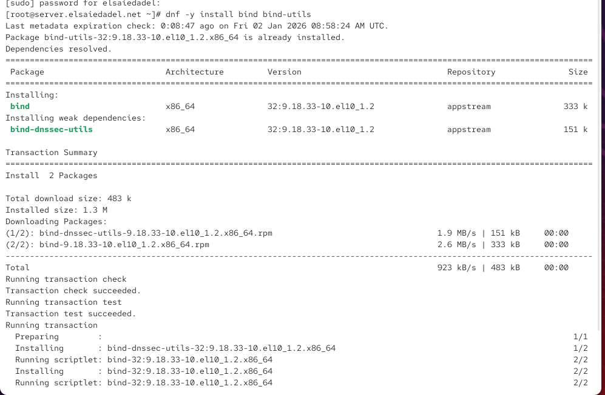

Установка bind и bind-utils

## Проверка DNS-разрешения

Для проверки работы DNS-клиента выполнен запрос к доменному имени www.yandex.ru.  
Получен корректный ответ со статусом NOERROR и набором A-записей.

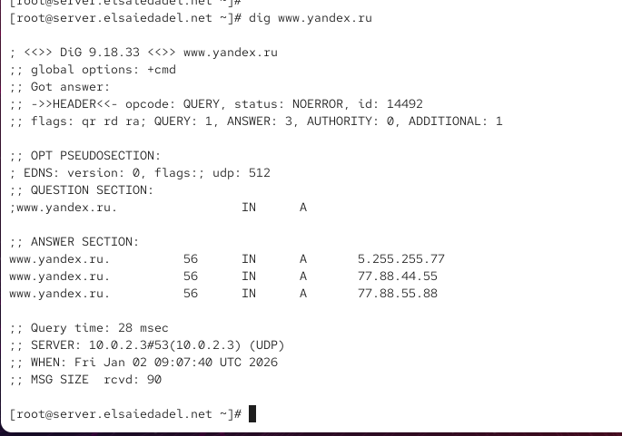

DNS-запрос dig

## Анализ конфигурационных файлов

Проанализированы основные конфигурационные файлы DNS: - /etc/resolv.conf — настройки DNS-клиента; - /etc/named.conf — основная конфигурация BIND.

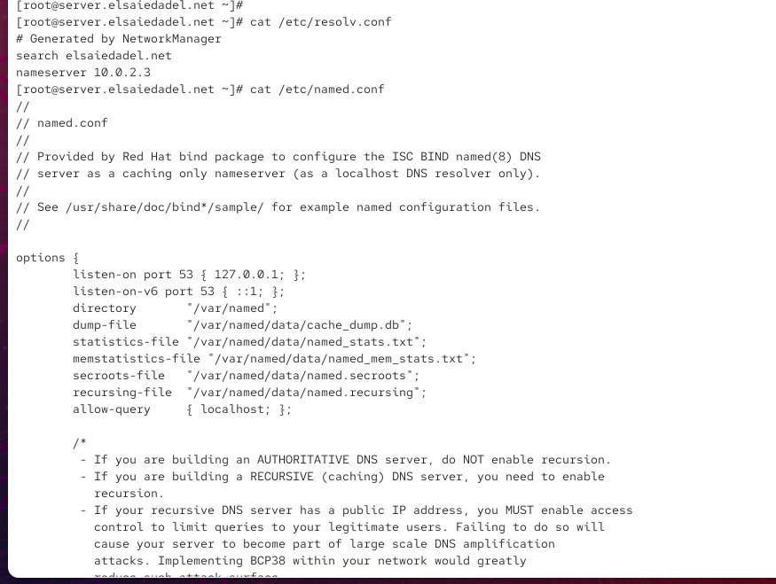

resolv.conf и named.conf

## Корневые DNS-серверы

Рассмотрен файл named.ca, содержащий сведения о корневых DNS-серверах Интернета, используемых для инициализации DNS-кэша.

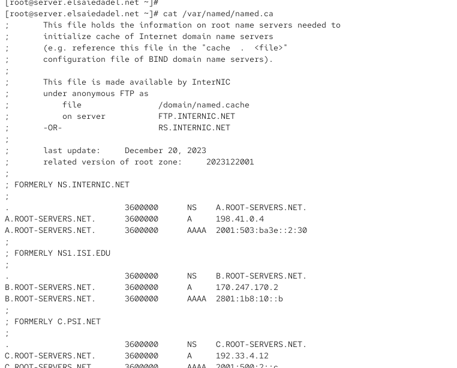

Файл named.ca

## Локальные зоны

Проанализированы файлы named.localhost и named.loopback, обеспечивающие корректную работу локального DNS-разрешения.

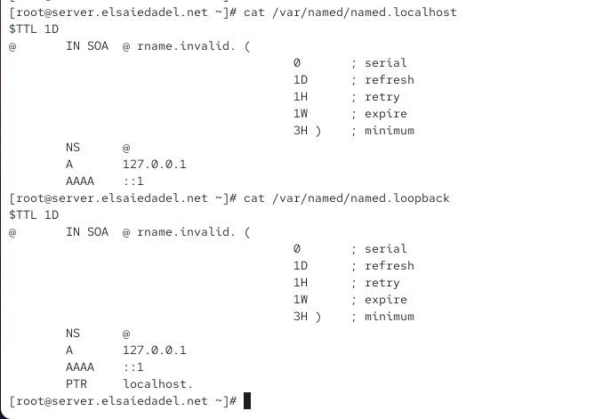

Локальные зоны

## Проверка локального DNS-сервера

Выполнен DNS-запрос с явным указанием локального сервера 127.0.0.1.  
Полученный ответ показал необходимость дополнительной настройки сервера.

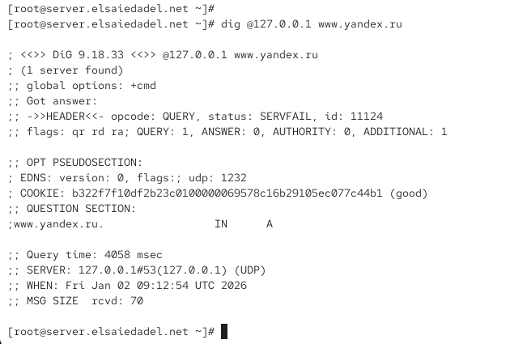

DNS-запрос через localhost

## Настройка DNS по умолчанию

Сетевое соединение eth0 настроено на использование DNS-сервера 127.0.0.1.  
Изменения подтверждены в файле resolv.conf.

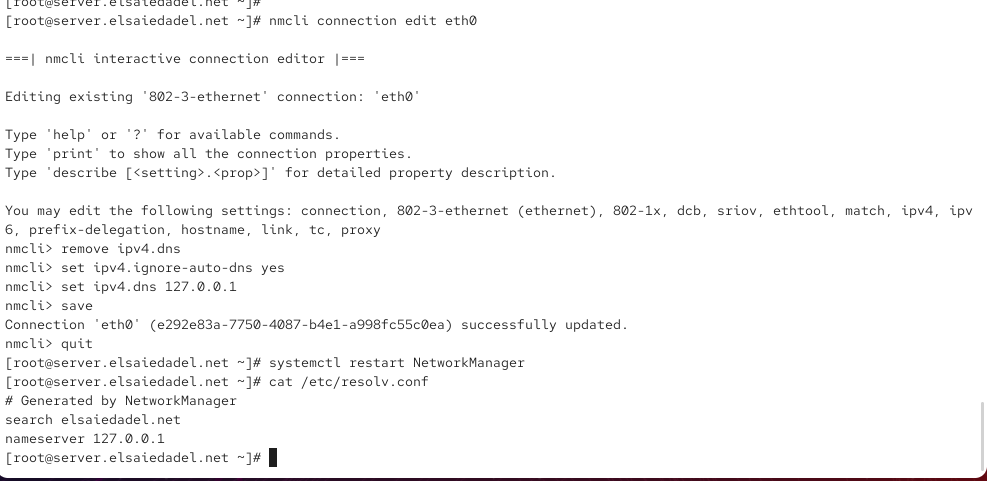

Настройка NetworkManager

## Разрешение запросов из сети

В файле named.conf разрешена обработка DNS-запросов от внутренней сети и включено прослушивание всех интерфейсов.

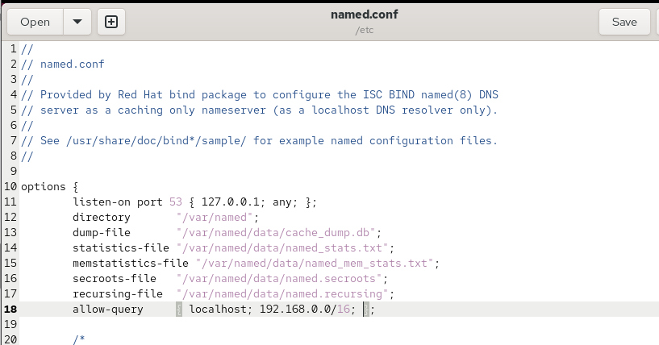

Изменение named.conf

## Проверка работы службы named

Проверено, что демон named прослушивает UDP-порт 53 и корректно обрабатывает DNS-запросы.

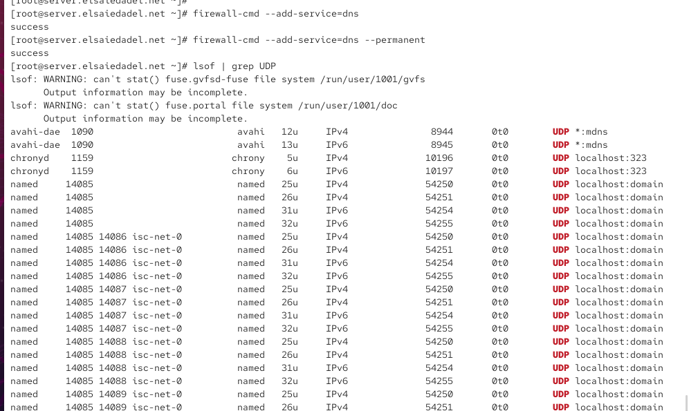

Проверка lsof

## Описание DNS-зон

Создан файл описания зон elsaiedadel.net и подключён в основной конфигурации named.

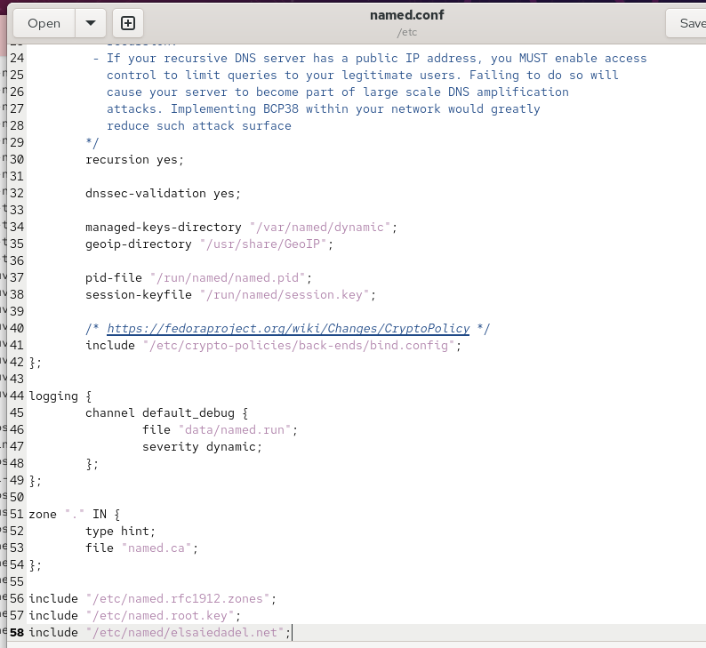

Файл зон

## Прямая и обратная зоны

Настроены: - прямая зона elsaiedadel.net; - обратная зона 1.168.192.in-addr.arpa.

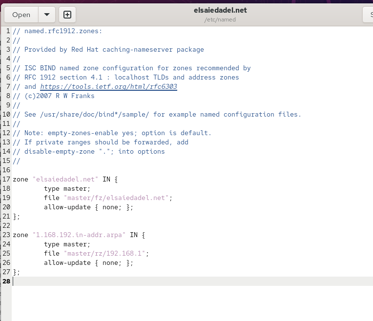

Описание зон

## Файл прямой зоны

В файле прямой зоны определены записи SOA, NS и A для домена elsaiedadel.net.

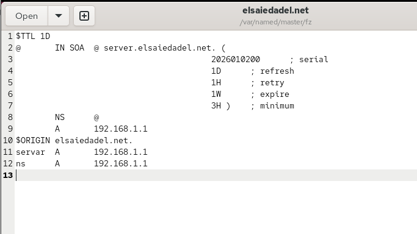

Прямая зона

## Файл обратной зоны

В файле обратной зоны заданы PTR-записи для IP-адреса 192.168.1.1.

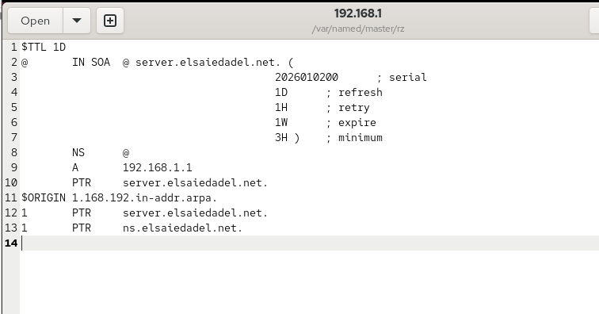

Обратная зона

## SELinux и права доступа

Выполнена настройка прав доступа и восстановление контекстов безопасности SELinux для корректной работы named.

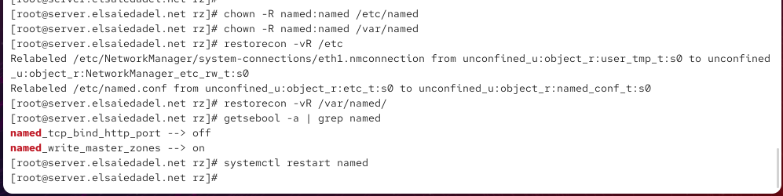

SELinux

## Проверка dig

Выполнен запрос к ns.elsaiedadel.net.  
Получен авторитативный ответ от локального DNS-сервера.

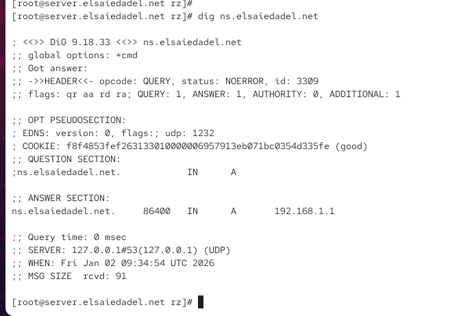

dig ns.elsaiedadel.net

## Проверка host

С помощью утилиты host проверены: - список записей зоны; - A-записи; - PTR-записи.

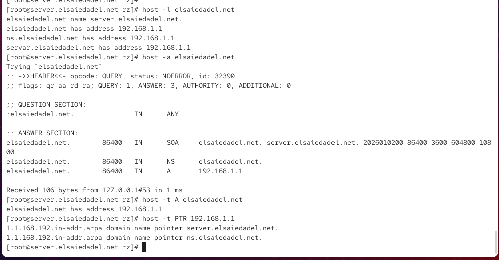

Проверка host

## Подготовка provisioning

Создана структура каталогов для хранения DNS-конфигурации в /vagrant/provision/server/dns и скопированы необходимые файлы.

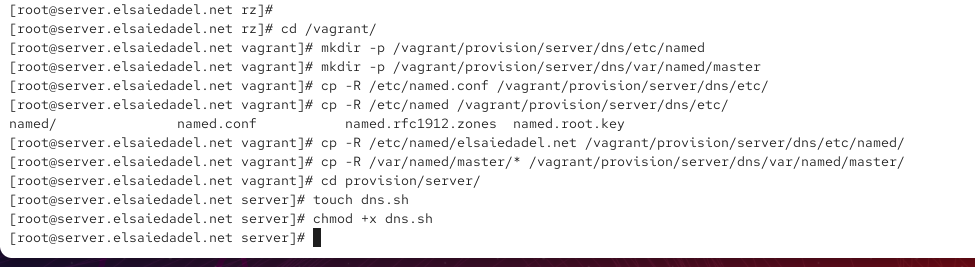

Подготовка каталогов

## Скрипт dns.sh

Создан provisioning-скрипт dns.sh, автоматизирующий установку, настройку и запуск DNS-сервера при старте виртуальной машины.

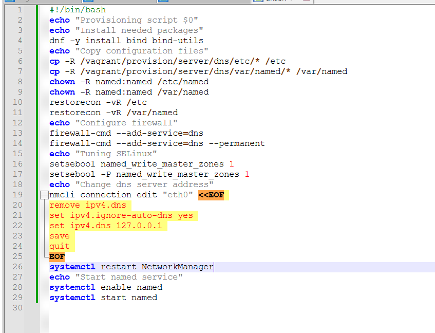

Скрипт dns.sh

# Выводы

## Вывод

В ходе лабораторной работы был установлен и настроен DNS-сервер на базе BIND. Реализована работа кэширующего и первичного DNS-сервера, настроены прямая и обратная зоны, проверена корректность разрешения имён и автоматизирован процесс развёртывания. Полученные результаты подтверждают корректную работу DNS-сервера и его готовность к использованию во внутренней виртуальной сети.